# MarineEcology_Tutorial

Jaime Grimm

2024-10-17

# Marine Ecology - Lab 4 Tutorial

## 1.1 Introduction

R is an open source programming language that is used extensively in the field of ecology and evolution. R is a powerful tool for conducting statistical analyses and creating plots, but can come with a bit of a learning curve if you are unfamiliar with programming. This guide will provide instructions for downloading and using R, including example code that will be helpful when you do your analysis for labs 4 & 5.

Note: there are questions throughout this tutorial that aim to aid in your understanding. These questions do not need to be addressed in your submitted lab report.

## 1.2 Installing R and R Studio

To begin, you will need to install R, as well as R studio, which is a helpful user interface for interacting with the programming language.

### 1.2.1 If you are a windows user:

First, follow the instructions to download R from the [**CRAN website**](https://cran.r-project.org/bin/windows/base/) for the most recent version: R-4.4.1 Run the .exe file that was just downloaded and follow the instructions on screen to install the downloaded software locally on your computer.

Go to the [**RStudio download page**](https://www.rstudio.com/products/rstudio/download/#download) and identify the free version for your operating system Under Installers select RStudio Desktop 2022.07.2+576 for your operating system Follow the on-screen instructions to download the software and install it on your local machine Once it’s installed, open RStudio to make sure it works and that you don’t get any error messages.

### 1.2.2 If you are a mac user:

Download R from the [**Cran website**](https://cran.r-project.org/bin/macosx/) Select the .pkg file for the latest R version Double click on the downloaded file to install R

Go to the [**RStudio download page**](https://www.rstudio.com/products/rstudio/download/#download) and identify the free version for your operating system Under Installers select RStudio Desktop 2022.07.2+576 for your operating system Follow the on-screen instructions to download the software and install it on your local machine Once it’s installed, open RStudio to make sure it works and that you don’t get any error messages.

### 1.2.3 If you are a linux user:

Follow the instructions for your distribution from [**CRAN**](https://cloud.r-project.org/bin/linux/) they provide information to get the most recent version of R for common distributions. For most distributions, you could use your package manager (e.g., for Debian/Ubuntu run sudo apt-get install r-base and for Fedora yum install R, but we don’t recommend this approach as the versions provided by this are usually out of date. In any case, make sure you have at least R 4.1.1.

Go to the [**RStudio download page**](https://www.rstudio.com/products/rstudio/download/#download) and identify the free version for your operating system Under Installers select RStudio Desktop 2022.07.2+576 for your operating system Follow the on-screen instructions to download the software and install it on your local machine Once it’s installed, open RStudio to make sure it works and that you don’t get any error messages.

## 2 Getting started in R

The first thing you’ll want to do when you open R studio is open a new script by pressing the + button in the top left corner. You’ll notice that the R studio interface has four panels. In the top left is your R script, where you will write and run code. The bottom left is the R console. You can also write and run code in this block, but it will not be saved for you to come back to in future sessions. The top right is the environment workspace that will keep track of all of the data and objects you create in your script, and the bottom right allows you to explore files, get help and view plots.

Next, you need to set your working directory. This is a filepath on your computer where you will save your script. This is also where you’ll need to save your datafiles to so that R knows where to look for them. You can do this by clicking “Session” > “Set working directory” > “Choose directory” and then navigate to the folder you will be working in. Alternatively, you can do this through code:

```r
#Set the working directory

#setwd("~/Documents/GitHub/MarineEcology_Tutorial")
#Note that this directory will be specific to your own computer - this is just an example.You will need to change this and remove the #.
```

### 2.1 Running code

To run a line of code on a windows computer, hold CTR and press ENTER. On a mac computer, hold CMD and press ENTER

### 2.2 Annotating code

You’ll notice above that I used the “#” symbol before some lines of text. This marks the following lines as “comments” and will not run as code. It is good practice to annotate your code with comments explaining what a line of code does, or why you chose to do something. These are great notes to yourself or others that visit your code in the future.

### 2.3 Opening excel files in R

Next, we’ll want to load our lab data into R as a dataframe (which is structurally similar to looking at your data in a spreadsheet). The first thing we need to do is make sure our data is in a format that R can read. Specifically, we want to remove any spaces or special characters and save our datasheet as a .csv (comma-delimited excel sheet) in the folder we plan to set as our working directory.

Now, we can load the data into R.

We’ll start by creating what R calls an object to refer to our data. Here, I’m calling my mock dataset “fish”. This dataset contains count data for three species of fish at three sites.

```r
fish <- read.csv("fish.csv")
#The arrow tells R that "fish" is an object that refers to our data
#Having trouble? Make sure you are working in the correct directory where you have saved your data file
```

We can explore our data. Try the following commands and see what it shows you about our dataset.

```r
head(fish)
```

```
##   site replicate bass pumpkinseed sucker
## 1    A         1    3          15      2
## 2    A         2    4          10      1
## 3    A         3    2           8      2
## 4    A         4    6           5      1
## 5    A         5    8           9      3
## 6    A         6    3          10      2
```

```r
str(fish)
```

```
## 'data.frame':    30 obs. of  5 variables:
##  $ site       : chr  "A" "A" "A" "A" ...
##  $ replicate  : int  1 2 3 4 5 6 7 8 9 10 ...
##  $ bass       : int  3 4 2 6 8 3 2 8 1 1 ...
##  $ pumpkinseed: int  15 10 8 5 9 10 14 7 8 3 ...
##  $ sucker     : int  2 1 2 1 3 2 3 2 4 6 ...
```

### 2.4 Get summary statistics

We can also explore the overall summary statistics of our data:

```r
summary(fish)
```

```
##      site             replicate         bass        pumpkinseed
##  Length:30          Min.   : 1.0   Min.   :1.000   Min.   : 3.00
##  Class :character   1st Qu.: 3.0   1st Qu.:2.000   1st Qu.: 8.00
##  Mode  :character   Median : 5.5   Median :3.000   Median :10.00
##                     Mean   : 5.5   Mean   :4.033   Mean   :10.03
##                     3rd Qu.: 8.0   3rd Qu.:6.000   3rd Qu.:12.75
##                     Max.   :10.0   Max.   :9.000   Max.   :16.00
##      sucker
##  Min.   :1.000
##  1st Qu.:2.000
##  Median :2.500
##  Mean   :2.833
##  3rd Qu.:4.000
##  Max.   :6.000
```

## 3 Analyzing differences in biodiversity among sites

In our lab, we’re interested in exploring biodiversity differences among sampling sites.

### 3.1 Calculating species abundance in each sample

We can start by calculating the total abundance of plankton across all species in each of our samples. In our dataframe, each row represents one sample, so we can calculate abundance by summing across the species counts per row, specifying the rows our species counts are in.

To do this calculation, we’ll use the rowSums() function in R. Each function comes with a set of arguments that are required for it to function. For rowSums() we need to provide: **x** - our data

```r
fish$abundance <- rowSums(x = fish[3:5])
#This line of code is doing a couple of things. First, by defining the object "fish$abundance" we are creating a new column in our dataframe with the title "abundance"
#Next, by adding the square brackets after "fish" we are specifying to the function that it should calculate the sum using columns 3-5 in our dataframe, which correspond to the fish counts for each species

#Take a look at how this changes our dataframe:
head(fish)
```

```
##   site replicate bass pumpkinseed sucker abundance
## 1    A         1    3          15      2        20
## 2    A         2    4          10      1        15
## 3    A         3    2           8      2        12
## 4    A         4    6           5      1        12
## 5    A         5    8           9      3        20
## 6    A         6    3          10      2        15
```

### 3.2 Calculating species richness in each sample

Richness is the number of species present in each site. In the mock dataset I’m using here, we only measured three species so it’s trivial to look at the data and count the number of species. But what if our dataset were more complex/had more species?

We could calculate ricness “manually” for each of our sites, or we can use a package* in R called vegan. You can find documentation about the vegan package here: https://cran.r-project.org/web/packages/vegan/vignettes/diversity-vegan.pdf

*Packages are sets of code that other people create for a given function and “package” for others to use.

To use a package, we first need to install it (remove the # to run this line of code if you don’t already have this package installed):

```r
#install.packages("vegan")
```

We then load our installed packages to be able to use them:

```r
library(vegan)
```

We can now use the specnumber() function in vegan to calculate richness. For specnumber() we need to provide: **x** - our data

```r
fish$richness <- specnumber(fish[,3:5])
#Again, I am creating a new column in our dataframe titled "richness" and specifying which columns (specified using the square brackets) the function should use to calculate the richness
#Take a look at how this has changed our dataframe
```

### 3.3 Calculating the Shannon Diversity Index for each sample

One common measure of biodiversity is the Shannon diversity index, which takes into account both species richness (number of species) and evenness (relative abundance of those species). Here, we will consider each of our sample replicates as a community.

The equation for the Shannon index ($H$) is: $H$ = $-\sum p_{i} * ln(p_{i})$

Where $p_i$ is the proportion of the entire community made up of species $i$

We could calculate the Shannon index “manually” for each of our sites, or we can use the diversity() function in vegan. For diversity() we need to provide: **x** - our data that we want to use to calculate the shannon index, **index** - which index we want to calculate (here, “shannon”)

```r
fish$shannon <- diversity(x = fish[,3:5], index = "shannon")
#Again, I am creating a new column in our dataframe titled "shannan" and specifying which columns (specified using the square brackets) the function should use to calculate the shannon index
#Take a look at how this has changed our dataframe
head(fish)
```

```
##   site replicate bass pumpkinseed sucker abundance richness   shannon
## 1    A         1    3          15      2        20        3 0.7305881
## 2    A         2    4          10      1        15        3 0.8033150
## 3    A         3    2           8      2        12        3 0.8675632
## 4    A         4    6           5      1        12        3 0.9184278
## 5    A         5    8           9      3        20        3 1.0104128
## 6    A         6    3          10      2        15        3 0.8608514
```

#### Question

We have now calculated a shannon index value for every replicate at every sample site. Why did we do this rather than first collapsing (e.g. by taking the mean) of each fish species at each site to only have one index value per site?

## 4 Making plots

There are two plotting libraries we’ll be using to make plots: The first is base plot, already included as a part of R. The second is ggplot2 -which is part of a larger set of packages in the “tidyverse”

If you’ve never used these packages before you’ll start by installing tidyverse:

```r
#install.packages("tidyverse")
```

Now load it:

```r
library(tidyverse)
```

First we will reorganize how our dataframe is organized by switching it from a *wide* format to a *long* format. Typically, wide formats are useful for data analysis, but long formats can be helpful for creating some types of plots. You can visualize and read about the differences in wide versus long data formats here: https://www.statology.org/long-vs-wide-data/. In this case, rather than have each individual species in our dataframe in it’s own column, we’re going to create a new column called “species” which will list the species, and one called “count” which will contain the number of each species in each site and replicate.

We are going to use the function pivot_longer() [see details here](https://tidyr.tidyverse.org/reference/pivot_longer.html), which requires the following arguments: **data** - our data, **cols** - the columns we want to pivot into longer format (we provide these as a vector using the c() function), **names_to** - the name of the column we want to put our previous column names into, and **values_to** - the name of the column we want to put our values into

```r
#Convert from wide to long data:
fish_long <- pivot_longer(data=fish, cols=c("bass", "pumpkinseed", "sucker"), names_to="species", values_to="count")

#Compare how fish_long looks compared to the previous dataframe (fish)
```

#### Question

What happens to our columns where we calculated abundance and the shannon index in our long dataframe? Does converting the format of our dataframe mess up these calculations?

Now we will make a stacked bar chart to explore the communities at each site. The syntax of ggplot can be confusing and take some getting used to. There are tons of resources available online to help you figure it out!

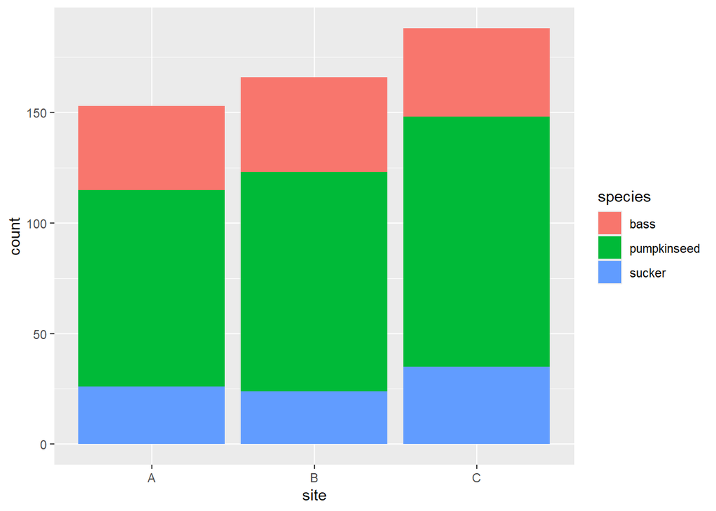

```r
ggplot(fish_long, aes(fill=species, y=count, x=site)) +
    geom_bar(position="stack", stat="identity")
```

```r
#Here I am telling ggplot() we want to plot data from our fish_long dataframe, using site as our x axis, count as our y values, and "filling" the colours based on each species. geom_bar() tells ggplot to make it a bar chart.

#ggplot has a ton of customizable features. Look up ggplot2 and change the colours, resize the axes and labels, edit the gridlines, etc.
```

We can also compare our data with basic box plots that show the distribution of the data:

```r
dev.off() #sometimes plotting in R acts up. We use this line of code to "clear" previous plotting instructions
```

```r
ggplot(fish_long, aes(x=site, y=count, fill=species)) +
    geom_boxplot()

#Here, I am using geom_boxplot() instead to change the type of plot we're making
#Again, customize your plots.
```

[output not shown]

### Question

What information does a boxplot provide that you can’t get in a bar chart? What do the horizontal and vertical lines represent?

## 5 Exploring environmental data

Load our environmental data:

```r
env <- read.csv("env_vars.csv")
str(env)
```

```
## 'data.frame':    3 obs. of  6 variables:
##  $ site    : chr  "A" "B" "C"
##  $ temp    : num  14.4 12.5 13.2
##  $ ph      : num  7.4 7.8 7.9
##  $ depth   : int  4 8 3
##  $ weather : chr  "Cloudy" "Cloudy" "Cloudy"
##  $ watercol: chr  "darkgreen" "greenishblue" "darkgreen"
```

Start by plotting variables. Here’s example code for temperature, but you’ll want to plot each variable

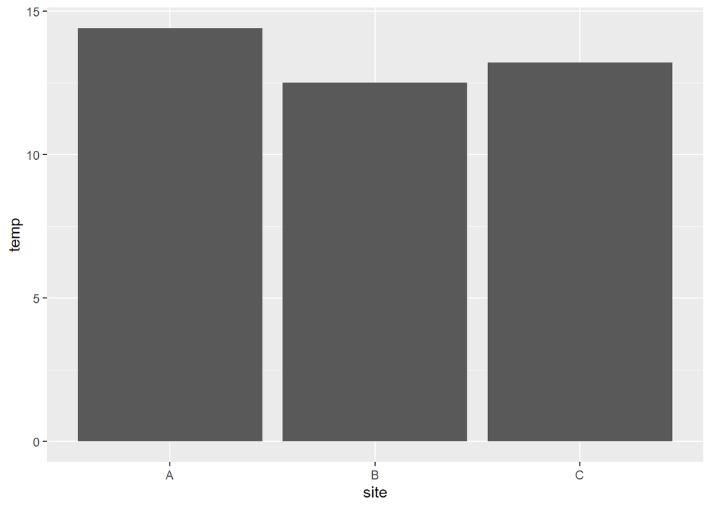

```r
ggplot(env, aes(y = temp, x = site)) +
    geom_bar(stat="identity")
```

#### Question:

How does this dataset differ from the fish dataset (hint: think about replication/variance in measurements)?

## 6 Comparing sites with an ANOVA and post-hoc analysis

ANOVAs are used to compare means among three or more groups (e.g. sites).

When performing the ANOVA, we must check that our data meet the assumptions of the test we are planning on carrying out.

The assumptions of the one-factor ANOVA are: 1) Observations are independent and random 2) Residuals are normally distributed 3) Variance of the residuals is constant (homoscedasticity).

### 6.1 Implementing an ANOVA in R

To illustrate, let’s say we want to test whether species abundance differs among sites.

We start by using the aov() function to create an object:

```r
#One-way ANOVA
abundance.anova <- aov(fish$abundance~fish$site) #use the aov function to execute the ANOVA

summary(abundance.anova) #check the degrees of freedom and p-value
```

```
##             Df Sum Sq Mean Sq F value Pr(>F)
## fish$site    2   62.6   31.30   2.012  0.153
## Residuals   27  420.1   15.56
```

Here, we don’t have a significant result.

### 6.2 Verifying test assumptions

Does our data meet the assumptions of the ANOVA? For assumption 1) independence of samples - this is determined by our sampling method. Were our samples taken independently? What correlations might exist?

We can verify the other two assumptions using diagnostic plots of the residuals:

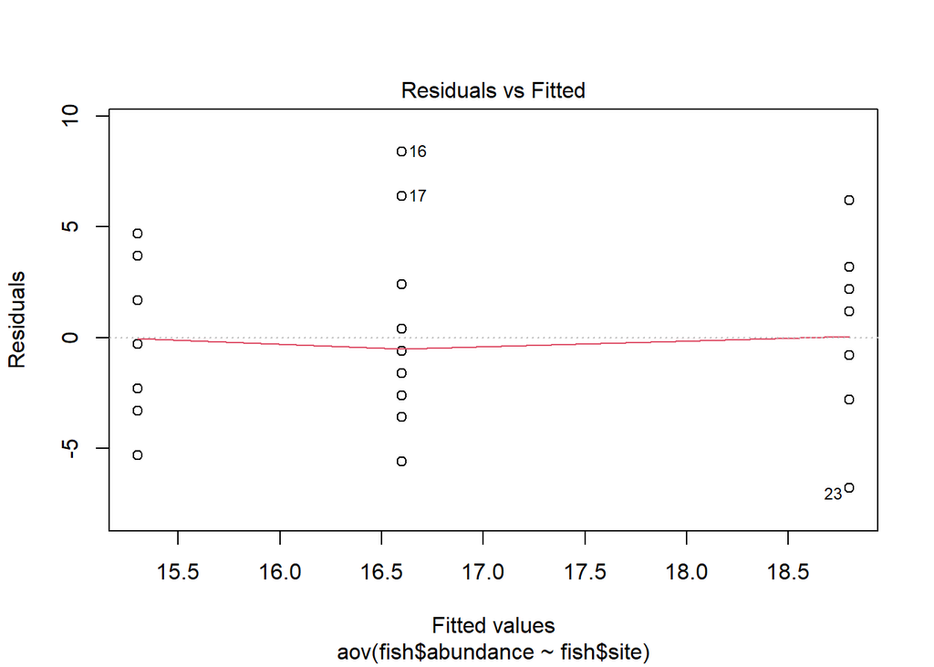

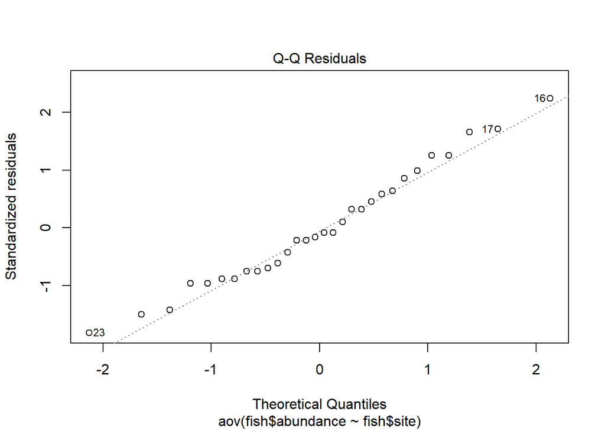

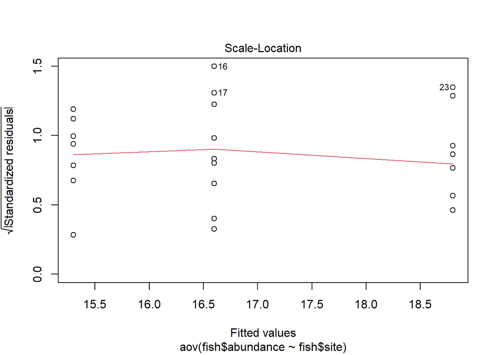

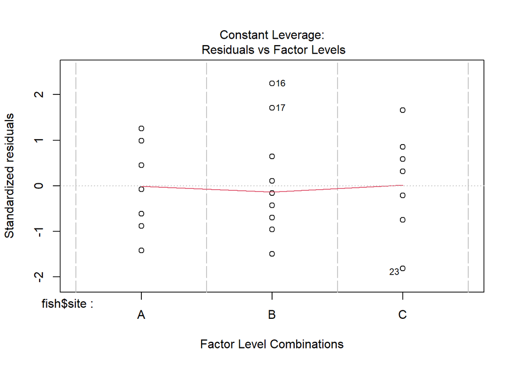

```r
plot(abundance.anova)
```

### 6.3 Interpreting residual plots On the first plot (residuals versus fitted), you want to check for assumption 3 - residuals are constant. Here, we’re looking for a more-or-less uniform band across sites. There shouldn’t be a clear pattern in how clustered the points are. This plot looks pretty good.

On the second plot (Normal Q-Q), you want to check for assumption 2 - that residuals follow a normal distribution. Here, we want most of the points to fall on the diagonal line. Again, this looks pretty good. You can also plot a histogram of the residuals to double check that this looks like a normal distribution:

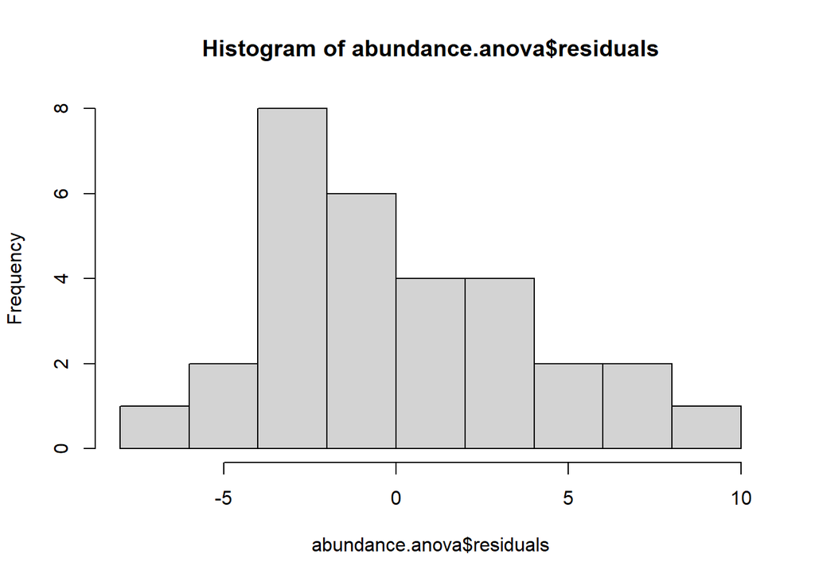

```r
hist(abundance.anova$residuals)
```

```r
#looks decent
```